# Projet_AS

kilian_ber

2023-11-16

# Projet Apprentissage statistique

Fontaine Aymeric

Tavian Matteo

Bertholon Kilian

## Etape 1 : Explication sur les données traitées.

Nous avons choisi de travailler sur des données de football. Ne trouvant pas de jeu de données intéresant. Nous avons donc choisi décidé de web-scrapper des données issus d’un site Internet. Nous avons décidé de travailer sur le site : https://redscores.com/fr/football-stats.

A l’aide d’un code Javascript construit pour cela nous avons pu récupérer les données issues de 42000 joueurs sur plus de 5 saisons (sur les 10 plus grands championnats mondiaux ainsi que 5 championnats de 2ème division.

Le code Javascript est disponible dans le dossier code Javascript.

Pour chacun des joueurs on dispose d’informations sur ses performances au court de l’année :

- Son nom
- Son poste
- Son club
- Son Age
- Le nombre de Minutes jouées dans l’années
- Le nombre d’apparitions (en match)
- Le nombre de but(s) qu’il a inscrit
- Le nombre de passe(s) décisive(s) qu’il a délivré
- Sa note moyenne sur l’ensemble de l’année
- Le nombre de tirs moyen par match
- Le nombre de dribbles moyen par match
- Le pourcentage de passes réussis par match
- La moyenne de passes clés par match
- Le pourcentage de centres réussis
- Le nombre de dégagement par match
- Le nombre d’interception moyens par match
- Le nombre de tacle moyen par match
- Le nombre de Tir bloqué moyen par match
- Le nombre de dribbles subis moyen par match
- Le nombre de faute moyen par match
- Le nombre de tacle moyen recu par match
- Le nombre de Hors-jeu moyen par match
- L’année de références des stastiques

## Etape 2 : Import des données et Pré-traitement

```r
#### Chargement des packages ####

library(jsonlite)
```

```r
library(tidyr)
library(ggplot2)
library(dplyr)
library(corrplot)
library(ggraph)
library(tidymodels)
library(xgboost)
library(doParallel)
library(vip)
library(plotly)
library(yardstick)
```

Dans cette partie, nous effectuerons les modifications nécessaires pour créer le dataframe que l’on utilisera à partir des JSON crée précédamment par le scrapping

```r
#Indiquer les années disponibles
year_available <- 2019:2023

#Boucle de création du dataframe à partir des nom de fichiers
for (annee in year_available) {
  fichier_data <- paste0("resultat_football_", annee, ".json")
  data <- fromJSON(fichier_data)

  top10 <- data$Top10_championnat
  hors_top10 <- data$Autres

  data <- rbind(top10, hors_top10)
  data = data[-1]

  data <- separate(data, info, into = c("Poste", "Club", "Age"), sep = ",\\s*")

  data$Age <- sub("yrs", "", data$Age)
  data$Passes_perc <- (as.numeric(sub("%", "", data$Passes_perc)))

  data <- data %>% rename(Apparences = CartonJaune)

  cols_to_convert <- c("Age", "minJ", "Apparences", "But", "PasseDecisive", "Note", "Tirs",
                       "Dribbles", "moy_passes", "centre_perc", "degagement", "interception",
                       "tacle", "tirsBloques", "driblesSubis", "fautes", "TaclesRecu", "HorsJeu")

  data[, cols_to_convert] <- lapply(data[, cols_to_convert], function(x) as.numeric(gsub("'", "", x)))

  data$Annee <- as.character(annee)

  assign(paste0("data_", annee), data)
}
all_data <- rbind(data_2023, data_2022, data_2021, data_2020, data_2019)

summary(all_data)
```

```
##      nom               Poste               Club                Age
##  Length:41600       Length:41600       Length:41600       Min.   :16.0
##  Class :character   Class :character   Class :character   1st Qu.:24.0
##  Mode  :character   Mode  :character   Mode  :character   Median :27.0
##                                                           Mean   :27.5
##                                                           3rd Qu.:31.0
##                                                           Max.   :46.0
##                                                           NA's   :959
##       minJ          Apparences         But         PasseDecisive
##  Min.   :   0.0   Min.   : 1.00   Min.   : 0.000   Min.   : 0.000
##  1st Qu.: 324.0   1st Qu.: 8.00   1st Qu.: 0.000   1st Qu.: 0.000
##  Median : 971.5   Median :16.00   Median : 0.000   Median : 0.000
##  Mean   :1154.6   Mean   :17.38   Mean   : 1.529   Mean   : 1.043
##  3rd Qu.:1821.0   3rd Qu.:27.00   3rd Qu.: 2.000   3rd Qu.: 1.000
##  Max.   :4410.0   Max.   :49.00   Max.   :43.000   Max.   :21.000
##
##       Note            Tirs           Dribbles       Passes_perc
##  Min.   :1.700   Min.   :0.0000   Min.   :0.0000   Min.   :  0.00
##  1st Qu.:6.600   1st Qu.:0.1000   1st Qu.:0.2000   1st Qu.:  0.00
##  Median :6.800   Median :0.4000   Median :0.6000   Median : 73.00
##  Mean   :6.779   Mean   :0.5466   Mean   :0.8665   Mean   : 55.23
##  3rd Qu.:7.000   3rd Qu.:0.8000   3rd Qu.:1.3000   3rd Qu.: 80.00
##  Max.   :9.300   Max.   :6.3000   Max.   :9.3000   Max.   :100.00
##  NA's   :2044
##    moy_passes      centre_perc      degagement  interception
##  Min.   :0.0000   Min.   :  0.0   Min.   :0    Min.   :0.0000
##  1st Qu.:0.1000   1st Qu.:  0.0   1st Qu.:0    1st Qu.:0.1000
##  Median :0.4000   Median : 14.3   Median :0    Median :0.5000
##  Mean   :0.5007   Mean   : 16.5   Mean   :0    Mean   :0.6055
##  3rd Qu.:0.8000   3rd Qu.: 26.2   3rd Qu.:0    3rd Qu.:1.0000
##  Max.   :6.0000   Max.   :100.0   Max.   :0    Max.   :6.0000
##
##      tacle         tirsBloques      driblesSubis        fautes
##  Min.   :0.0000   Min.   :0.0000   Min.   :0.0000   Min.   :0.00
##  1st Qu.:0.3000   1st Qu.:0.0000   1st Qu.:0.2000   1st Qu.:0.40
##  Median :0.8000   Median :0.1000   Median :0.4000   Median :0.70
##  Mean   :0.9125   Mean   :0.1613   Mean   :0.4713   Mean   :0.75
##  3rd Qu.:1.4000   3rd Qu.:0.2000   3rd Qu.:0.7000   3rd Qu.:1.10
##  Max.   :8.0000   Max.   :5.0000   Max.   :6.0000   Max.   :5.00
##
##    TaclesRecu        HorsJeu     Annee
##  Min.   :0.0000   Min.   :0   Length:41600
##  1st Qu.:0.3000   1st Qu.:0   Class :character
##  Median :0.6000   Median :0   Mode  :character
##  Mean   :0.6836   Mean   :0
##  3rd Qu.:1.0000   3rd Qu.:0
##  Max.   :6.0000   Max.   :0
##
```

## Etape 3 : Première analyses visuelles sur les données

### Analyse des distributions variables par variables

#### a) Répartition par postes

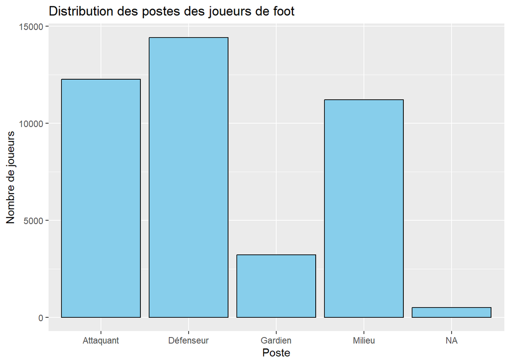

```r
#Les postes étaient avant des postes précis (milieu offensif droit par exemple. Par soucis de compréhension nous remplacons ces postes par 4 modalités (Gardien, défenseur, milieu et attaquant))
all_data <- all_data %>%
  mutate(Poste_global = case_when(
    Poste %in% c("AM", "CF", "LW", "RW") ~ "Attaquant",
    Poste %in% c("CB", "DF", "LB", "RB") ~ "Défenseur",
    Poste %in% c("CM", "DM", "LM", "MF", "RM") ~ "Milieu",
    Poste == "GK" ~ "Gardien",
    Poste == '' ~ NA,
    TRUE ~ "Autre"
  ))
ggplot(all_data, aes(x = Poste_global)) +
  geom_bar(fill = "skyblue", color = "black") +
  labs(title = "Distribution des postes des joueurs de foot",
       x = "Poste",
       y = "Nombre de joueurs")
```

#### b) Age

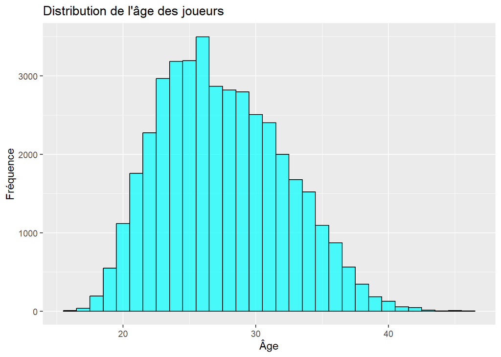

```r
# Créez un histogramme de l'âge
ggplot(all_data, aes(x = Age)) +
  geom_histogram(binwidth = 1, fill = "cyan", color = "black", alpha = 0.7) +
  labs(title = "Distribution de l'âge des joueurs", x = "Âge", y = "Fréquence")
```

#### c) But

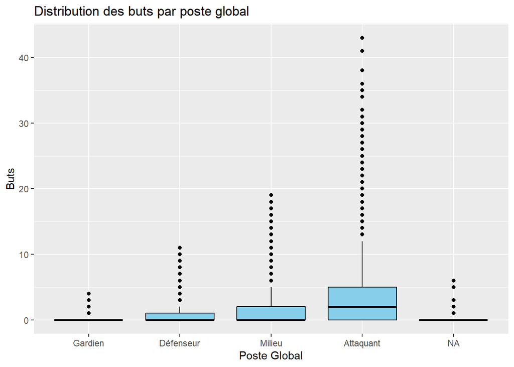

```r
all_data$Poste_global <- factor(all_data$Poste_global, levels = c("Gardien", "Défenseur", "Milieu", "Attaquant", "NA"))

ggplot(all_data, aes(x = Poste_global, y = But)) +
  geom_boxplot(fill = "skyblue", color = "black") +
  labs(title = "Distribution des buts par poste global",
       x = "Poste Global",
       y = "Buts")
```

#### d) Passes décisives

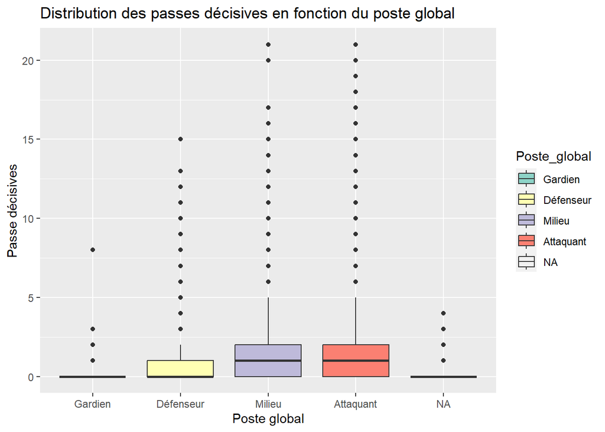

```r
# Créez un boxplot pour la distribution des passes décisives en fonction du poste global
ggplot(all_data, aes(x = Poste_global, y = PasseDecisive, fill = Poste_global)) +
  geom_boxplot() +
  labs(title = "Distribution des passes décisives en fonction du poste global", x = "Poste global", y = "Passe décisives") +
  scale_fill_brewer(palette = "Set3")  # Vous pouvez changer la palette de couleurs selon vos préférences
```

#### e) Minutes jouées

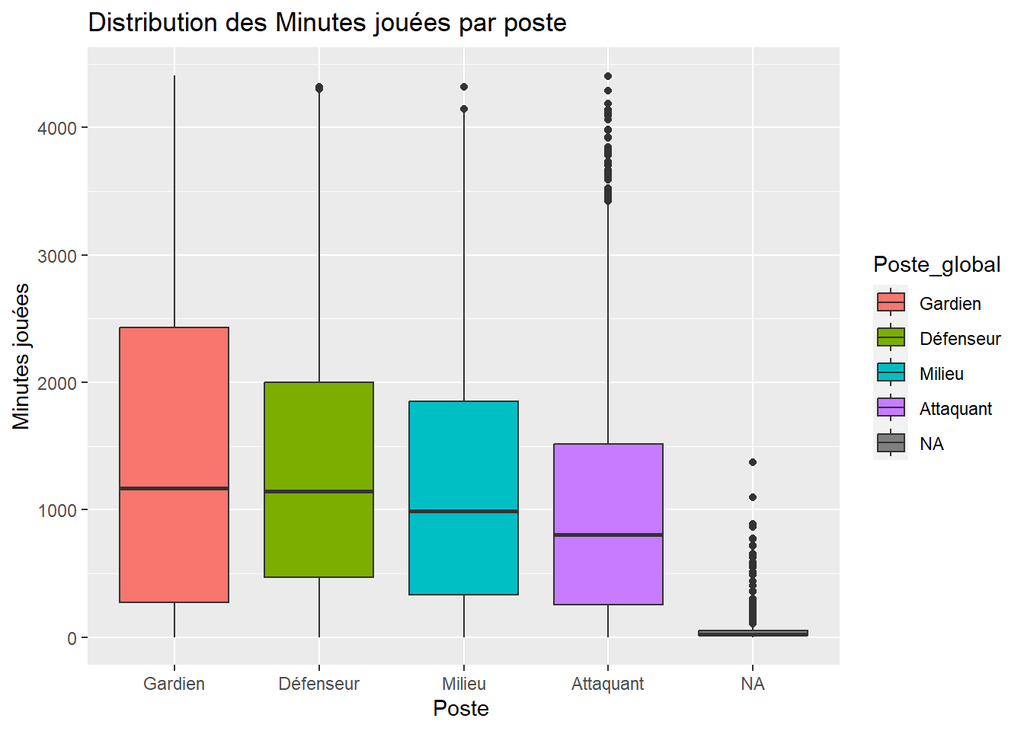

```r
Min_joue_poste<- ggplot(all_data, aes(x = Poste_global, y = minJ, fill = Poste_global)) +
  geom_boxplot() +  # Utiliser un boxplot pour la distribution
  labs(title = "Distribution des Minutes jouées par poste ",
       x = "Poste ",
       y = "Minutes jouées")

# Afficher le graphique
print(Min_joue_poste)
```

#### f) Apparitions

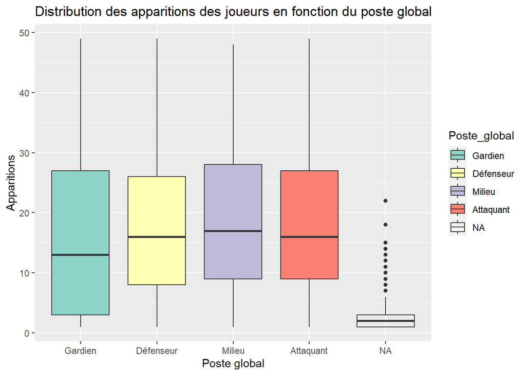

```r
# Créez un boxplot pour la distribution des passes décisives en fonction du poste global
ggplot(all_data, aes(x = Poste_global, y = Apparences, fill = Poste_global)) +
  geom_boxplot() +
  labs(title = "Distribution des apparitions des joueurs en fonction du poste global", x = "Poste global", y = "Apparitions") +
  scale_fill_brewer(palette = "Set3")  # Vous pouvez changer la palette de couleurs selon vos préférences
```

#### g) Note

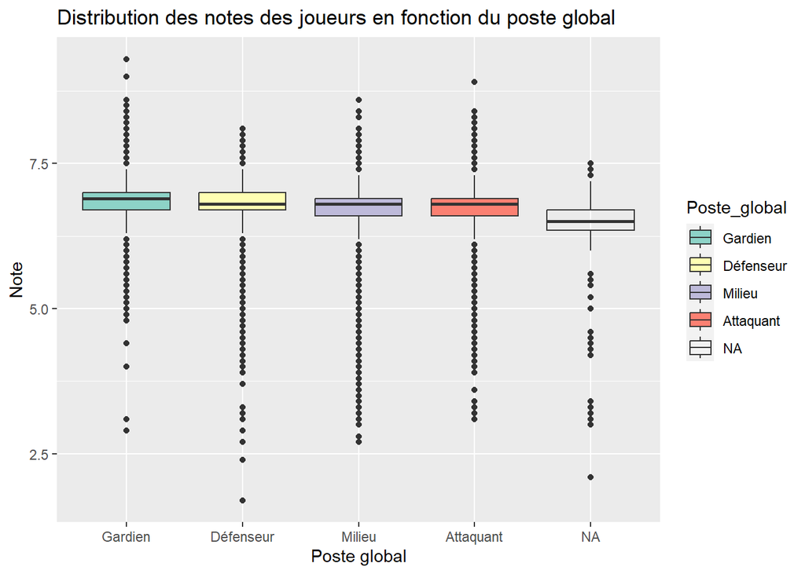

```r
# Créez un boxplot pour la distribution des Notes fonction du poste global
ggplot(all_data, aes(x = Poste_global, y = Note, fill = Poste_global)) +
  geom_boxplot() +
  labs(title = "Distribution des notes des joueurs en fonction du poste global", x = "Poste global", y = "Note") +
  scale_fill_brewer(palette = "Set3")  # Vous pouvez changer la palette de couleurs selon vos préférences
```

#### h) Tirs

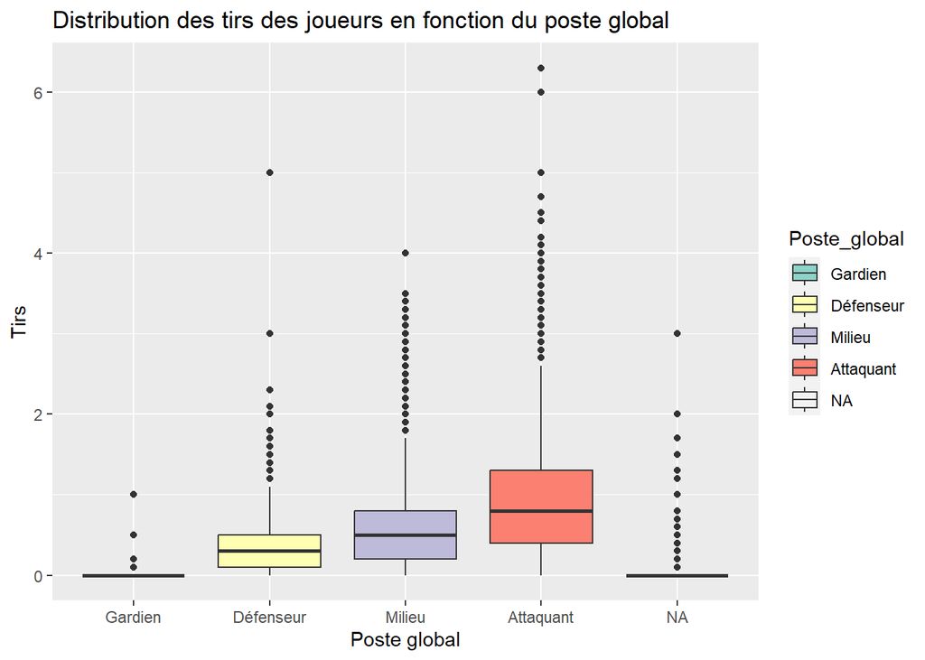

```r
ggplot(all_data, aes(x = Poste_global, y = Tirs, fill = Poste_global)) +
  geom_boxplot() +
  labs(title = "Distribution des tirs des joueurs en fonction du poste global", x = "Poste global", y = "Tirs") +
  scale_fill_brewer(palette = "Set3")
```

#### i) Dribbles

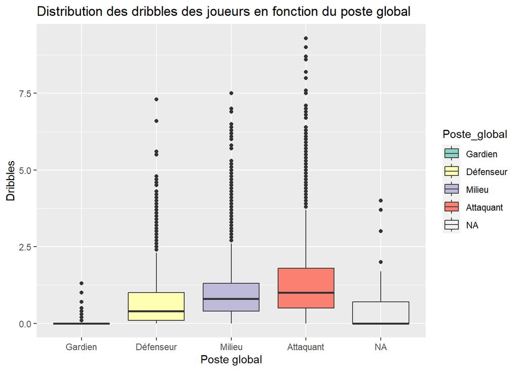

```r
ggplot(all_data, aes(x = Poste_global, y = Dribbles , fill = Poste_global)) +
  geom_boxplot() +
  labs(title = "Distribution des dribbles des joueurs en fonction du poste global", x = "Poste global", y = "Dribbles") +
  scale_fill_brewer(palette = "Set3")
```

#### j) Passes Pourcentages

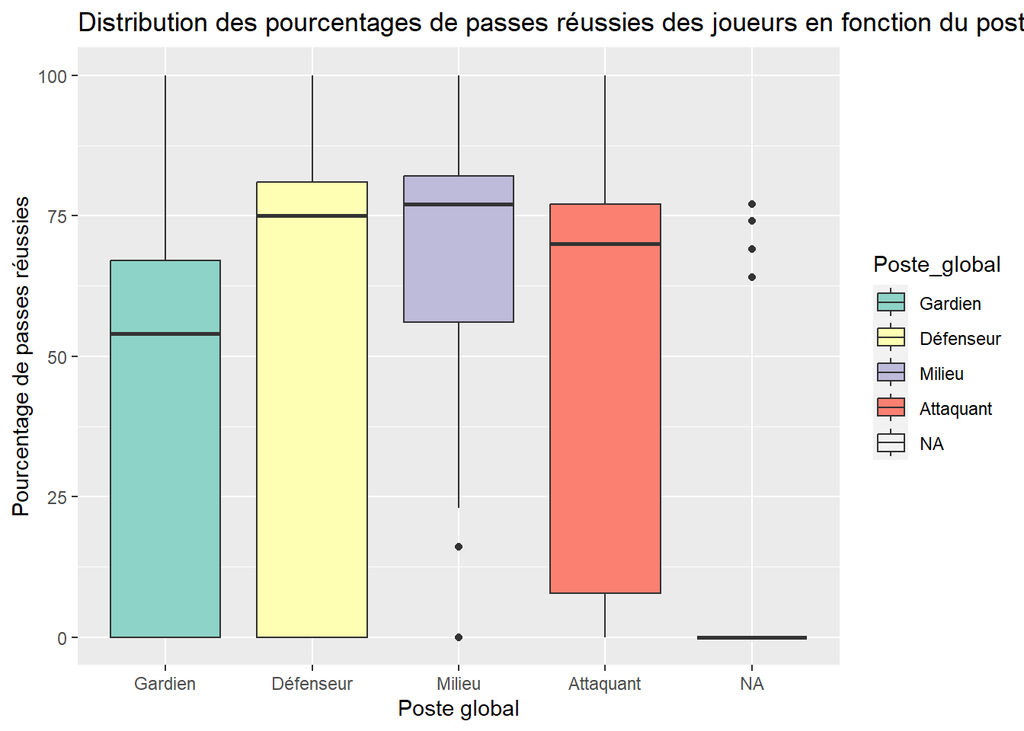

```r
ggplot(all_data, aes(x = Poste_global, y = Passes_perc , fill = Poste_global)) +
  geom_boxplot() +
  labs(title = "Distribution des pourcentages de passes réussies des joueurs en fonction du poste global", x = "Poste global", y = "Pourcentage de passes réussies") +
  scale_fill_brewer(palette = "Set3")
```

#### k) Moyenne passe clé

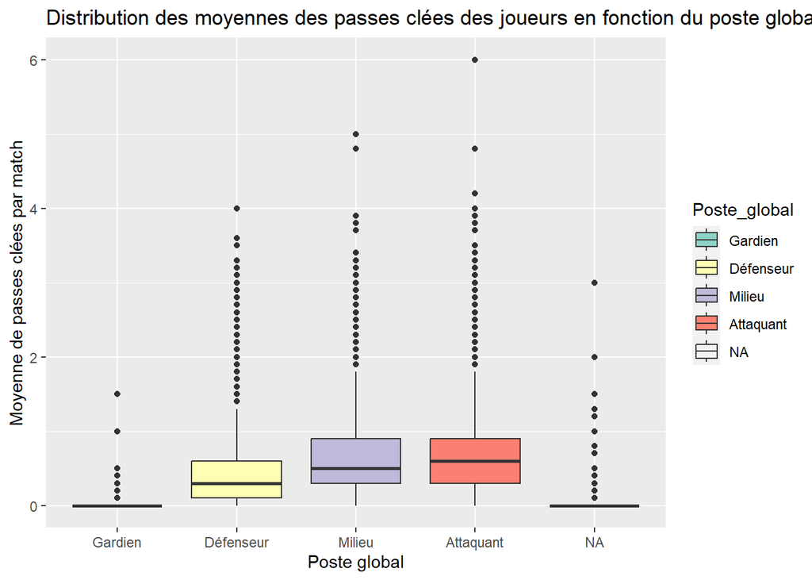

```r
ggplot(all_data, aes(x = Poste_global, y = moy_passes , fill = Poste_global)) +
  geom_boxplot() +
  labs(title = "Distribution des moyennes des passes clées des joueurs en fonction du poste global", x = "Poste global", y = "Moyenne de passes clées par match") +
  scale_fill_brewer(palette = "Set3")
```

#### l) Centre pourcentage

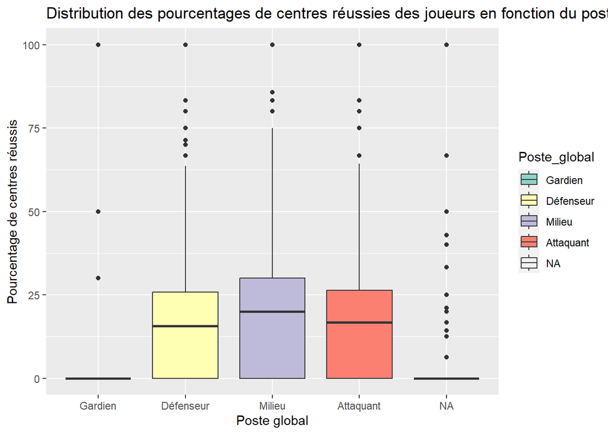

```r
ggplot(all_data, aes(x = Poste_global, y = centre_perc , fill = Poste_global)) +
  geom_boxplot() +
  labs(title = "Distribution des pourcentages de centres réussies des joueurs en fonction du poste global", x = "Poste global", y = "Pourcentage de centres réussis") +
  scale_fill_brewer(palette = "Set3")
```

#### m) Dégagement

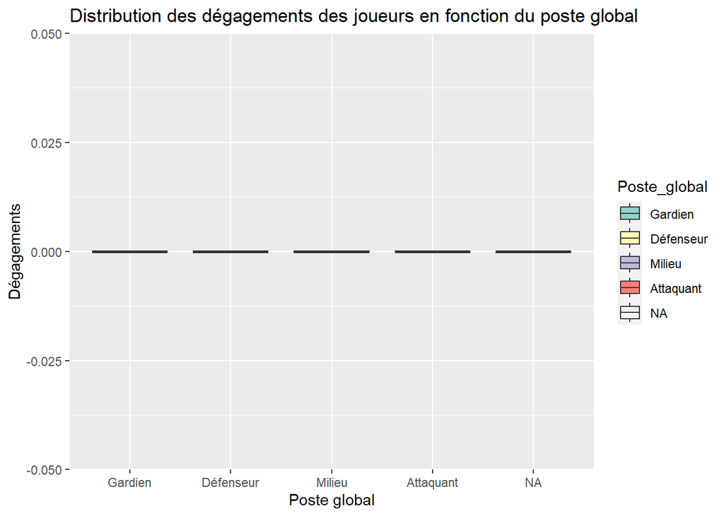

```r
ggplot(all_data, aes(x = Poste_global, y = degagement , fill = Poste_global)) +
  geom_boxplot() +
  labs(title = "Distribution des dégagements des joueurs en fonction du poste global", x = "Poste global", y = "Dégagements") +
  scale_fill_brewer(palette = "Set3")
```

On voit que tout les boxplots quelque soit le poste sont situées à 0. Cela signifie que toute la colonne “degagement” du jeu de données est constituée de 0. Cette variable n’est donc pas nécessaire, on peut la supprimer.

```r
all_data <- subset(all_data, select = -degagement)
```

#### n) Interception

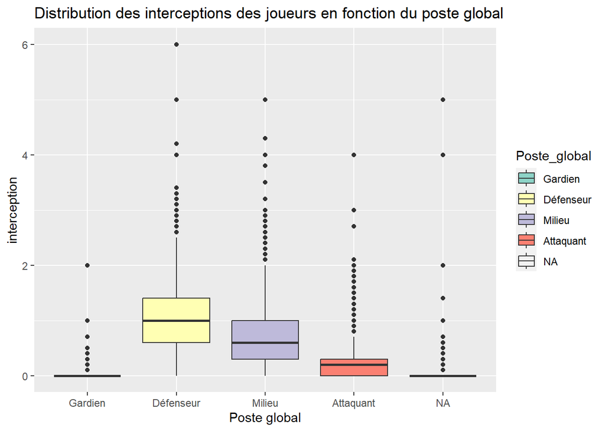

```r
ggplot(all_data, aes(x = Poste_global, y = interception , fill = Poste_global)) +
  geom_boxplot() +
  labs(title = "Distribution des interceptions des joueurs en fonction du poste global", x = "Poste global", y = "interception") +
  scale_fill_brewer(palette = "Set3")
```

#### o) Tacles recus

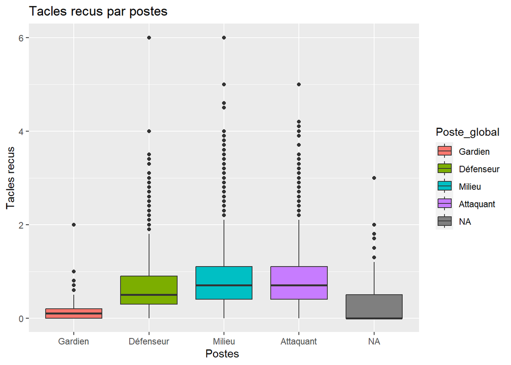

```r
ggplot(all_data, aes(x = Poste_global, y = TaclesRecu, fill = Poste_global)) +
  geom_boxplot() +
  labs(title = "Tacles recus par postes",
       x = "Postes ",
       y = "Tacles recus")
```

#### p) Tirs bloques

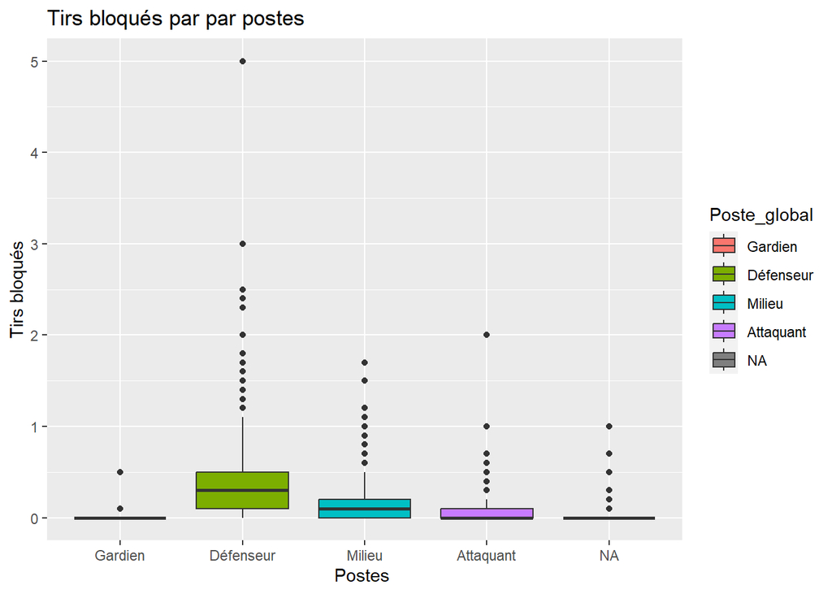

```r
ggplot(all_data, aes(x = Poste_global, y = tirsBloques, fill = Poste_global)) +
  geom_boxplot() +
  labs(title = "Tirs bloqués par par postes",
       x = "Postes ",
       y = "Tirs bloqués")
```

#### q) Dribles subis

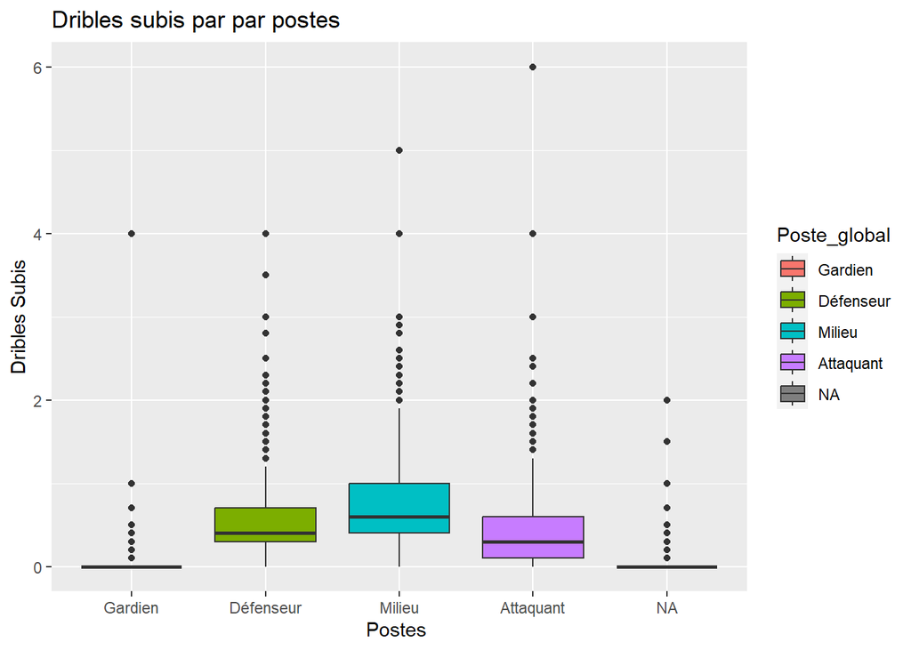

```r
ggplot(all_data, aes(x = Poste_global, y = driblesSubis, fill = Poste_global)) +
  geom_boxplot() +
  labs(title = "Dribles subis par par postes",
       x = "Postes ",
       y = "Dribles Subis")
```

#### r) Fautes commises moyennes par match

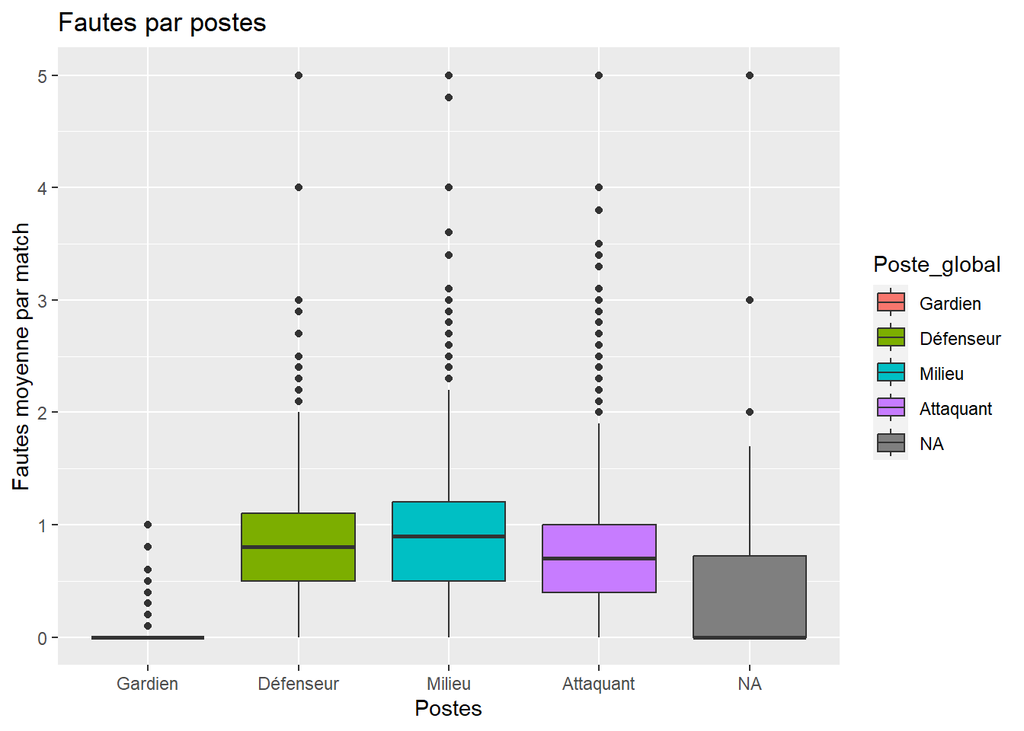

```r
ggplot(all_data, aes(x = Poste_global, y = fautes, fill = Poste_global)) +
  geom_boxplot() +
  labs(title = "Fautes par postes",
       x = "Postes",
       y = "Fautes moyenne par match")
```

#### s) Tacles recu

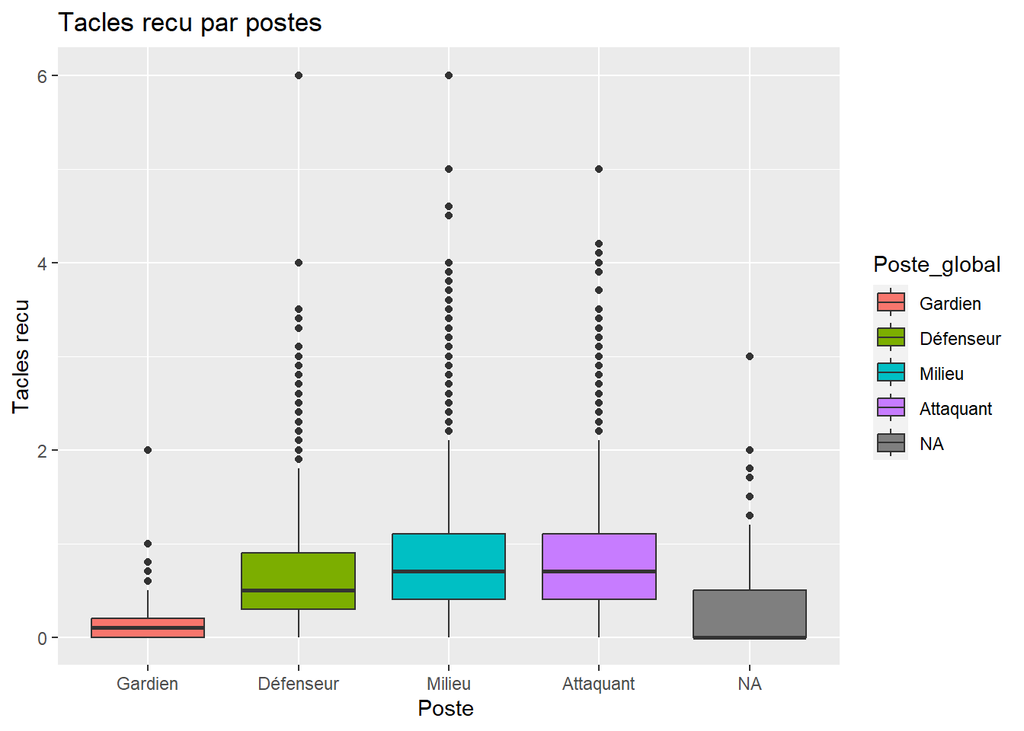

```r
ggplot(all_data, aes(x = Poste_global, y = TaclesRecu, fill = Poste_global)) +
  geom_boxplot() +
  labs(title = "Tacles recu par postes",
       x = "Poste ",
       y = "Tacles recu")
```

#### t) Hors jeu

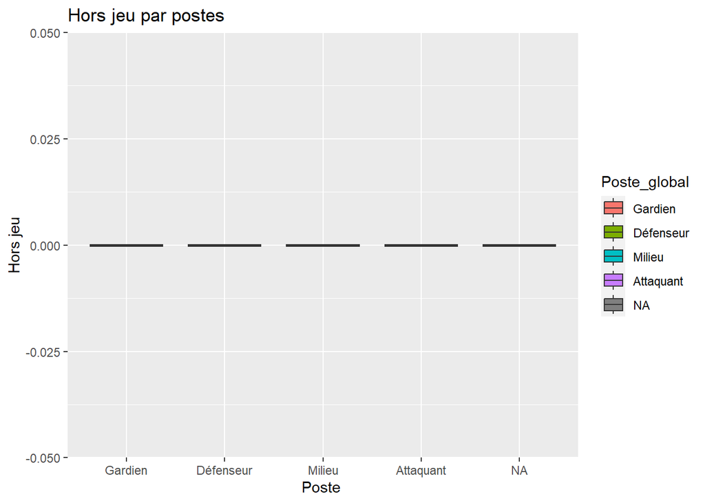

```r
ggplot(all_data, aes(x = Poste_global, y = HorsJeu, fill = Poste_global)) +
  geom_boxplot() +
  labs(title = "Hors jeu par postes",
       x = "Poste ",
       y = "Hors jeu")
```

On voit ici que les Hors jeu sont nul pour chacunes des modalités. On peut donc substituer cette colonne dans le cas ou nos données ne seront pas completées par de nouvelles données comportant des hors-jeu

```r
all_data <- subset(all_data, select = -HorsJeu)
```

#### u) Annee

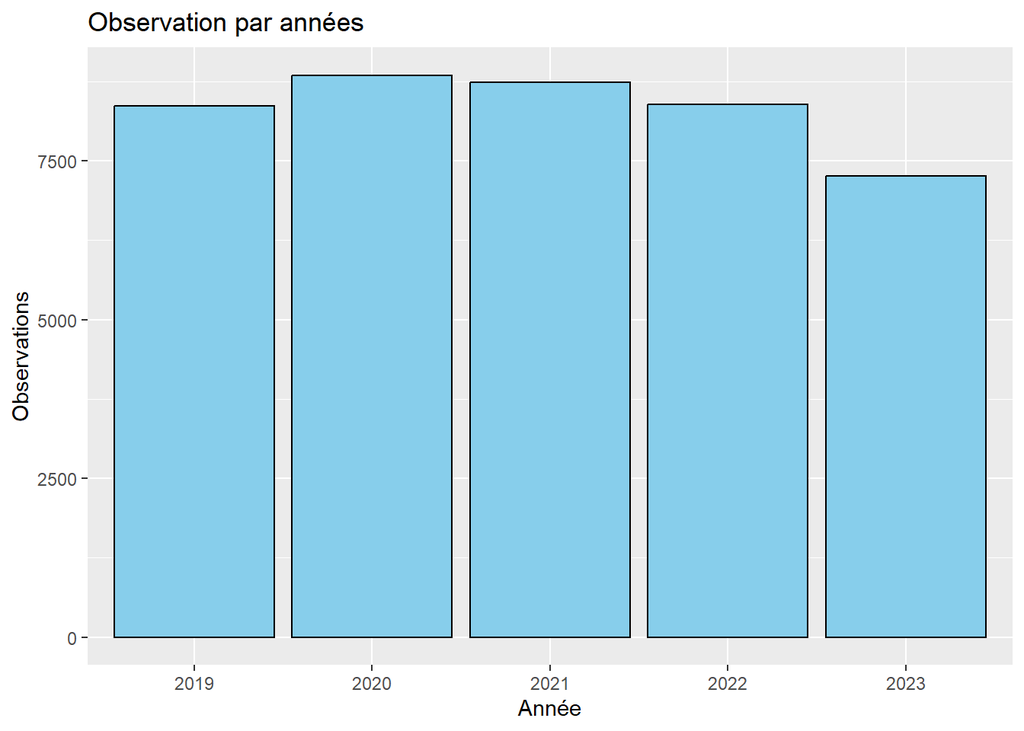

```r
table_annee <- data.frame(table(all_data$Annee))

ggplot(table_annee, aes(x = Var1, y = Freq)) +
  geom_bar(stat = "identity", fill = "skyblue", color = "black") +
  labs(title = "Observation par années",
       x = "Année",
       y = "Observations")
```

### Analyse des corrélations globales

On peut penser que certaines variables peuvent être corrélées. Selon le modèle que l’on utilise ca pourrait éventuellement nous poser problèmes. On va donc étudier cela.

Nous avons seulement des variables quantitatives –> corrélations de Pearson

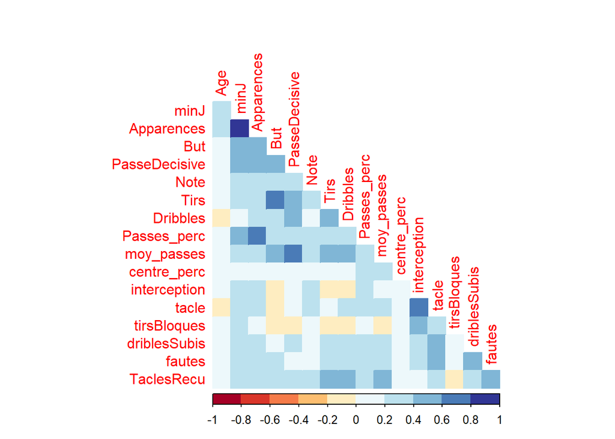

```r
# Sélectionner seulement les colonnes avec des variables quantitatives
variables_quantitatives <- all_data %>%
  select_if(is.numeric)

variables_quantitatives <- na.omit(variables_quantitatives)

# Calculer la matrice de corrélation
matrice_correlation <- cor(variables_quantitatives, use = "complete.obs")

# Afficher une heatmap avec corrplot
corrplot(matrice_correlation, method = "color", type = "lower", diag = FALSE, col = COL2('RdYlBu', 10))
```

Quelques variables paraissent un peu corrélées :

- Minutes jouées avec le nombre d’apparitions ( ce qui parait logique )
- Le nombre de but avec le nombre de tirs
- Le nombre de passe clés avec le nombre de passes décisives
- Le pourcentage de passes avec le nombre d’apparritions
- Le nombre d’interception avec le nombre de tacles

## Etape 4 : Identification des probématiques potentielles :

Dans le cadre du footbal, plusieurs problématiques peuvent se poser devant nous avec les données dont nous disposons :

1. *Essayer de calculer la note des joueurs à partir de leurs statistiques*
2. Essayer d’identifier des performances futures à partir des performances passées
3. Essayer de confirmer des choix de l’entraineurs (visualisables à partir de apparitions et des minutes jouées)
4. Essayer d’identifier des critères de performances pour chacuns des postes

# 1) Note des joueurs

Le site sur lesquel nous avons recolté nos données permet d’obtenir les notes de chaque joueurs. Nous aimerions pouvoir recalculer les notes de chacun des joueurs à partir de leurs statistiques.

Cependant, nos connaissances de la disciplines nous indiquent que les notes des joueurs à partir des statistiques seront dépendantes du postes (un attaquant qui effectue plus de tirs sera avantagé car c’est ce qu’on lui demande)

L’ensemble de nos variables sont quantitatives : Nous allons donc pouvoir essayer plusieurs modèles différents afin d’estimer aux plus justes les notes des joueurs.

Dans un premier temps, il va donc falloir préparer nos données pour rassembler les joueurs par postes.

Notre démarche s’effectuera de tel sorte :

## Pré-traitement des données

### Rassembler les joueurs par postes

```r
Gardien <- all_data |> filter(Poste_global == "Gardien")
Defenseur <- all_data |> filter(Poste_global == "Défenseur")
Milieu <- all_data |> filter(Poste_global == "Milieu")
Attaquant <- all_data |> filter(Poste_global == "Attaquant")
```

### Etudier la distribution des notes par postes

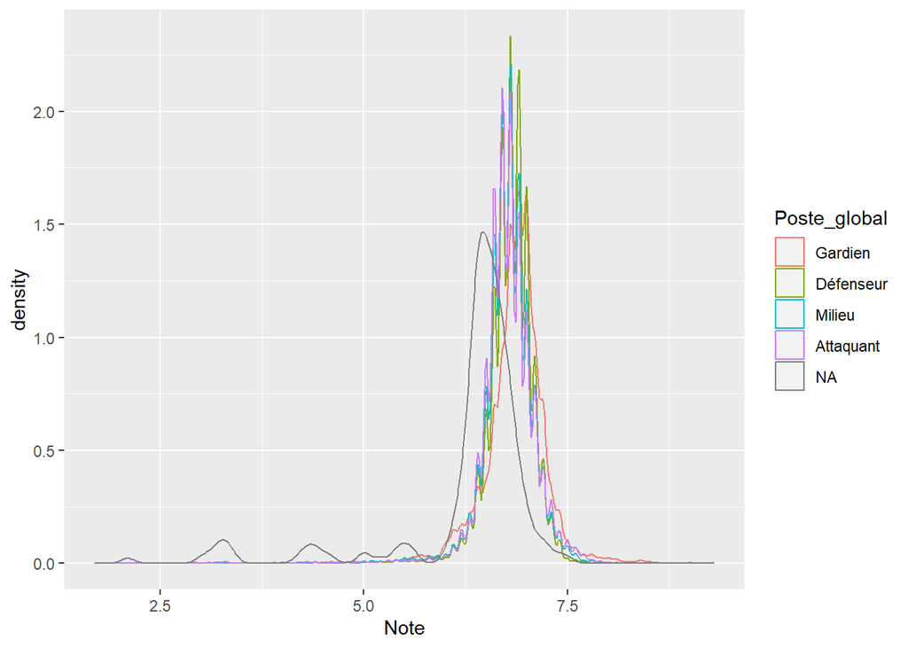

```r
density <- ggplot(all_data, aes(Note, color = Poste_global)) + geom_density()
density
```

On semble plutot suivre une loin normale sur chacun des notes des différents postes

## Utilisation des différents algorithmes

### Attaquant

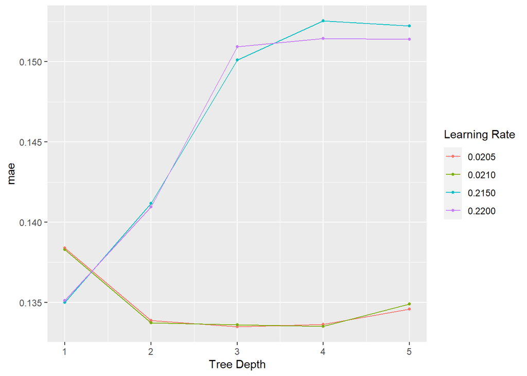

```r
all_data_attaquant <- subset(Attaquant, select = -c(nom, Poste, Club, Annee, Poste_global))
all_data_attaquant <- na.omit(all_data_attaquant, cols = "Note")

#Diviser en entrainement et test
set.seed(123)
data_split_att <- initial_split(all_data_attaquant, prop = 0.75, strata = Note)
data_train_att <- training(data_split_att)
data_test_att <- testing(data_split_att)

#Préparation des données
variable_a_tester_xg <- c("Age","minJ","Apparences","But","PasseDecisive","Tirs","Dribbles","Passes_perc","moy_passes","centre_perc","interception","tacle","tirsBloques","driblesSubis","fautes","TaclesRecu")
recipe_xg_att <- recipe(Note ~ ., data = data_train_att) |>
  update_role(all_of(variable_a_tester_xg), new_role = "predictor") |>
  step_normalize(all_predictors())

xgb_model_att <-
  boost_tree(
    trees = 1000,
    stop_iter=20,
    min_n = 1,
    tree_depth = tune(),
    learn_rate = tune()
  ) |>
  set_mode("regression") |>
  set_engine("xgboost")

xgb_wf_att <- workflow() |>
  add_recipe(recipe_xg_att) |>
  add_model(xgb_model_att)

play_samples_cv_att <- vfold_cv(data_train_att,v=3,repeats=1,strata="Note")

xgb_grid <- expand.grid(tree_depth=c(1,2,3,4,5),learn_rate=c(0.0205,0.0210, 0.215,0.220))

xgb_3fold_att <- xgb_wf_att |>
  tune_grid(resamples=play_samples_cv_att,grid=xgb_grid,
            metrics=metric_set(mae))

xgb_3fold_att |> autoplot()
```

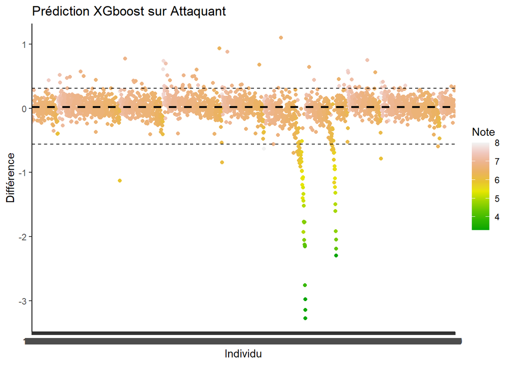

```r
best_par_att <- xgb_3fold_att |>
  select_best()

final_xgb_att <- xgb_wf_att |>
  finalize_workflow(best_par_att) |>
  fit(data = data_train_att)

pred_att <- final_xgb_att |>
  predict(new_data=data_test_att)


data_test_att_fin <- data_test_att |> select(Note)
data_test_att_fin_2 <- cbind(pred_att, data_test_att_fin)

data_test_att_fin_2$Difference <- data_test_att_fin_2$Note - data_test_att_fin_2$.pred
data_test_att_fin_2$DifferenceAbs <- abs(data_test_att_fin_2$Note - data_test_att_fin_2$.pred)


# Calculer la médiane et les intervalles de confiance
median_diff_att <- median(data_test_att_fin_2$Difference)
ci_low_att <- quantile(data_test_att_fin_2$Difference, 0.025)
ci_high_att <- quantile(data_test_att_fin_2$Difference, 0.975)

# Créer le plot ggplot2 avec médiane et intervalles de confiance
gg_plot_att <- ggplot(data_test_att_fin_2, aes(x = rownames(data_test_att_fin_2), y = Difference, color = Note)) +
  geom_point() +
  geom_hline(yintercept = median_diff_att, linetype = "dashed", color = "black", size = 1) +
  geom_hline(yintercept = ci_low_att, linetype = "dashed", color = "black", size = 0.5)+
  geom_hline(yintercept = ci_high_att, linetype = "dashed", color = "black", size = 0.5)+
  labs(title = "Prédiction XGboost sur Attaquant",
       x = "Individu",
       y = "Différence") +
  scale_colour_gradientn(colours = terrain.colors(10)) +
  theme_classic()
gg_plot_att
```

```r
R2_att_xg <- 1 - sum((data_test_att_fin_2$Note - data_test_att_fin_2$.pred)^2) / sum((data_test_att_fin_2$Note - mean(data_test_att_fin_2$Note))^2)
RMSE_att_xg <- sqrt(mean((data_test_att_fin_2$Note - data_test_att_fin_2$.pred)^2))
erreur_moy_abs_att_xg <- mean(data_test_att_fin_2$DifferenceAbs)
```

### Milieu

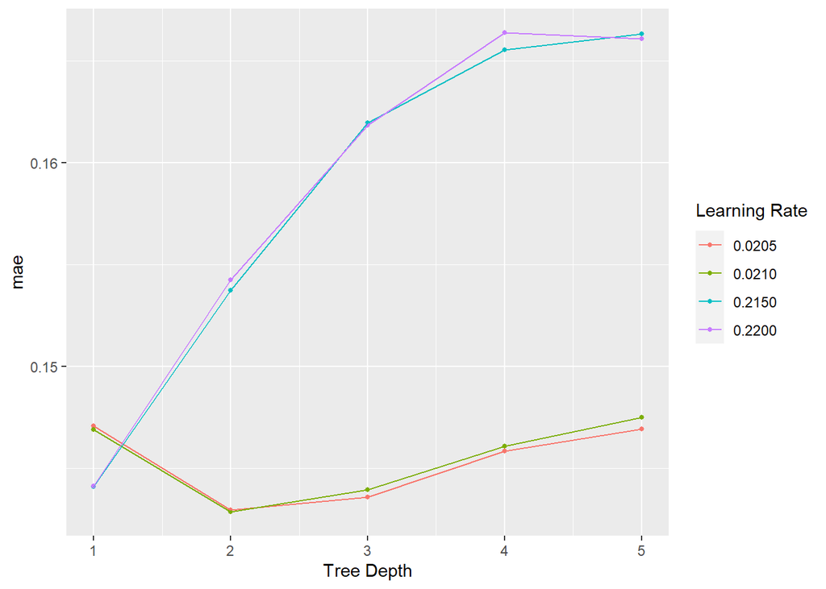

```r
all_data_milieu <- subset(Milieu, select = -c(nom, Poste, Club, Annee, Poste_global))
all_data_milieu <- na.omit(all_data_milieu, cols = "Note")

#Diviser en entrainement et test
set.seed(123)
data_split_mil <- initial_split(all_data_milieu, prop = 0.75, strata = Note)
data_train_mil <- training(data_split_mil)
data_test_mil <- testing(data_split_mil)

#Préparation des données
variable_a_tester_xg <- c("Age","minJ","Apparences","But","PasseDecisive","Tirs","Dribbles","Passes_perc","moy_passes","centre_perc","interception","tacle","tirsBloques","driblesSubis","fautes","TaclesRecu")
recipe_xg_mil <- recipe(Note ~ ., data = data_train_mil) |>
  update_role(all_of(variable_a_tester_xg), new_role = "predictor") |>
  step_normalize(all_predictors())

xgb_model_mil <-
  boost_tree(
    trees = 1000,
    stop_iter=20,
    min_n = 1,
    tree_depth = tune(),
    learn_rate = tune()
  ) |>
  set_mode("regression") |>
  set_engine("xgboost")

xgb_wf_mil <- workflow() |>
  add_recipe(recipe_xg_mil) |>
  add_model(xgb_model_mil)

play_samples_cv_mil <- vfold_cv(data_train_mil,v=3,repeats=1,strata="Note")

xgb_grid <- expand.grid(tree_depth=c(1,2,3,4,5),learn_rate=c(0.0205,0.0210, 0.215,0.220))

xgb_3fold_mil <- xgb_wf_mil |>
  tune_grid(resamples=play_samples_cv_mil,grid=xgb_grid,
            metrics=metric_set(mae))

xgb_3fold_mil |> autoplot()
```

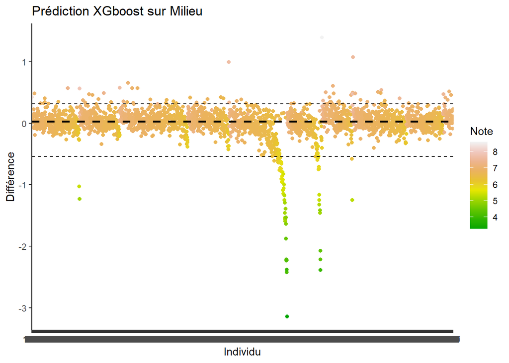

```r
best_par_mil <- xgb_3fold_mil |>
  select_best()

final_xgb_mil <- xgb_wf_mil |>
  finalize_workflow(best_par_mil) |>
  fit(data = data_train_mil)

pred_mil <- final_xgb_mil |>
  predict(new_data=data_test_mil)


data_test_mil_fin <- data_test_mil |> select(Note)
data_test_mil_fin_2 <- cbind(pred_mil, data_test_mil_fin)

data_test_mil_fin_2$Difference <- data_test_mil_fin_2$Note - data_test_mil_fin_2$.pred
data_test_mil_fin_2$DifferenceAbs <- abs(data_test_mil_fin_2$Note - data_test_mil_fin_2$.pred)


# Calculer la médiane et les intervalles de confiance
median_diff_mil <- median(data_test_mil_fin_2$Difference)
ci_low_mil <- quantile(data_test_mil_fin_2$Difference, 0.025)
ci_high_mil <- quantile(data_test_mil_fin_2$Difference, 0.975)

# Créer le plot ggplot2 avec médiane et intervalles de confiance
gg_plot_mil <- ggplot(data_test_mil_fin_2, aes(x = rownames(data_test_mil_fin_2), y = Difference, color = Note)) +
  geom_point() +
  geom_hline(yintercept = median_diff_mil, linetype = "dashed", color = "black", size = 1) +
  geom_hline(yintercept = ci_low_mil, linetype = "dashed", color = "black", size = 0.5)+
  geom_hline(yintercept = ci_high_mil, linetype = "dashed", color = "black", size = 0.5)+
  labs(title = "Prédiction XGboost sur Milieu",
       x = "Individu",
       y = "Différence") +
  scale_colour_gradientn(colours = terrain.colors(10)) +
  theme_classic()

gg_plot_mil
```

```r
R2_mil_xg <- 1 - sum((data_test_mil_fin_2$Note - data_test_mil_fin_2$.pred)^2) / sum((data_test_mil_fin_2$Note - mean(data_test_mil_fin_2$Note))^2)
RMSE_mil_xg <- sqrt(mean((data_test_mil_fin_2$Note - data_test_mil_fin_2$.pred)^2))
erreur_moy_abs_mil_xg <- mean(data_test_mil_fin_2$DifferenceAbs)
```

### Défenseur

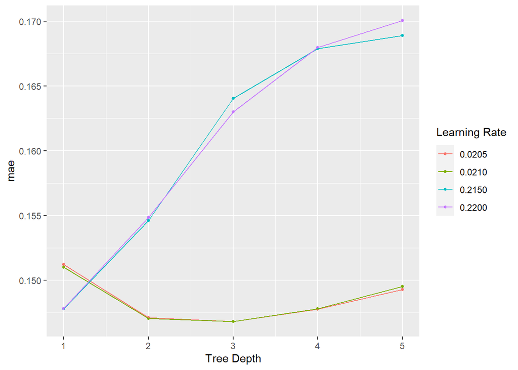

```r
all_data_defenseur <- subset(Defenseur, select = -c(nom, Poste, Club, Annee, Poste_global))
all_data_defenseur <- na.omit(all_data_defenseur, cols = "Note")

#Diviser en entrainement et test
set.seed(123)
data_split_def <- initial_split(all_data_defenseur, prop = 0.75, strata = Note)
data_train_def <- training(data_split_def)
data_test_def <- testing(data_split_def)

#Préparation des données
variable_a_tester_xg <- c("Age","minJ","Apparences","But","PasseDecisive","Tirs","Dribbles","Passes_perc","moy_passes","centre_perc","interception","tacle","tirsBloques","driblesSubis","fautes","TaclesRecu")
recipe_xg_def <- recipe(Note ~ ., data = data_train_def) |>
  update_role(all_of(variable_a_tester_xg), new_role = "predictor") |>
  step_normalize(all_predictors())

xgb_model_def <-
  boost_tree(
    trees = 1000,
    stop_iter=20,
    min_n = 1,
    tree_depth = tune(),
    learn_rate = tune()
  ) |>
  set_mode("regression") |>
  set_engine("xgboost")

xgb_wf_def <- workflow() |>
  add_recipe(recipe_xg_def) |>
  add_model(xgb_model_def)

play_samples_cv_def <- vfold_cv(data_train_def,v=3,repeats=1,strata="Note")

xgb_grid <- expand.grid(tree_depth=c(1,2,3,4,5),learn_rate=c(0.0205,0.0210, 0.215,0.220))

xgb_3fold_def <- xgb_wf_def |>
  tune_grid(resamples=play_samples_cv_def,grid=xgb_grid,
            metrics=metric_set(mae))

xgb_3fold_def |> autoplot()
```

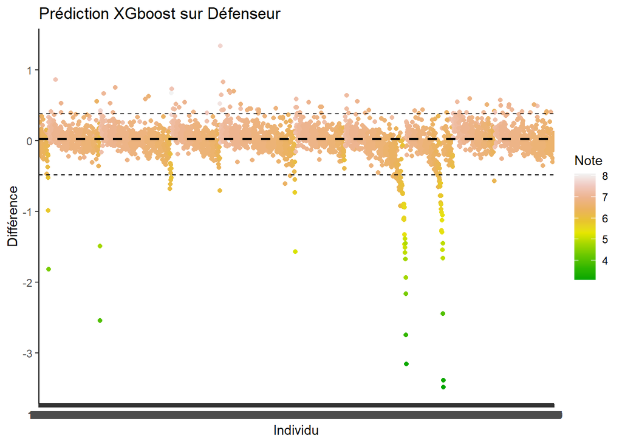

```r
best_par_def <- xgb_3fold_def |>
  select_best()

final_xgb_def <- xgb_wf_def |>
  finalize_workflow(best_par_def) |>
  fit(data = data_train_def)

pred_def <- final_xgb_def |>
  predict(new_data=data_test_def)


data_test_def_fin <- data_test_def |> select(Note)
data_test_def_fin_2 <- cbind(pred_def, data_test_def_fin)

data_test_def_fin_2$Difference <- data_test_def_fin_2$Note - data_test_def_fin_2$.pred
data_test_def_fin_2$DifferenceAbs <- abs(data_test_def_fin_2$Note - data_test_def_fin_2$.pred)


# Calculer la médiane et les intervalles de confiance
median_diff_def <- median(data_test_def_fin_2$Difference)
ci_low_def <- quantile(data_test_def_fin_2$Difference, 0.025)
ci_high_def <- quantile(data_test_def_fin_2$Difference, 0.975)

# Créer le plot ggplot2 avec médiane et intervalles de confiance
gg_plot_def <- ggplot(data_test_def_fin_2, aes(x = rownames(data_test_def_fin_2), y = Difference, color = Note)) +
  geom_point() +
  geom_hline(yintercept = median_diff_def, linetype = "dashed", color = "black", size = 1) +
  geom_hline(yintercept = ci_low_def, linetype = "dashed", color = "black", size = 0.5)+
  geom_hline(yintercept = ci_high_def, linetype = "dashed", color = "black", size = 0.5)+
  labs(title = "Prédiction XGboost sur Défenseur",
       x = "Individu",
       y = "Différence") +
  scale_colour_gradientn(colours = terrain.colors(10)) +
  theme_classic()

gg_plot_def
```

```r
R2_def_xg <- 1 - sum((data_test_def_fin_2$Note - data_test_def_fin_2$.pred)^2) / sum((data_test_def_fin_2$Note - mean(data_test_def_fin_2$Note))^2)
RMSE_def_xg <- sqrt(mean((data_test_def_fin_2$Note - data_test_def_fin_2$.pred)^2))
erreur_moy_abs_def_xg <- mean(data_test_def_fin_2$DifferenceAbs)
```

### Gardien

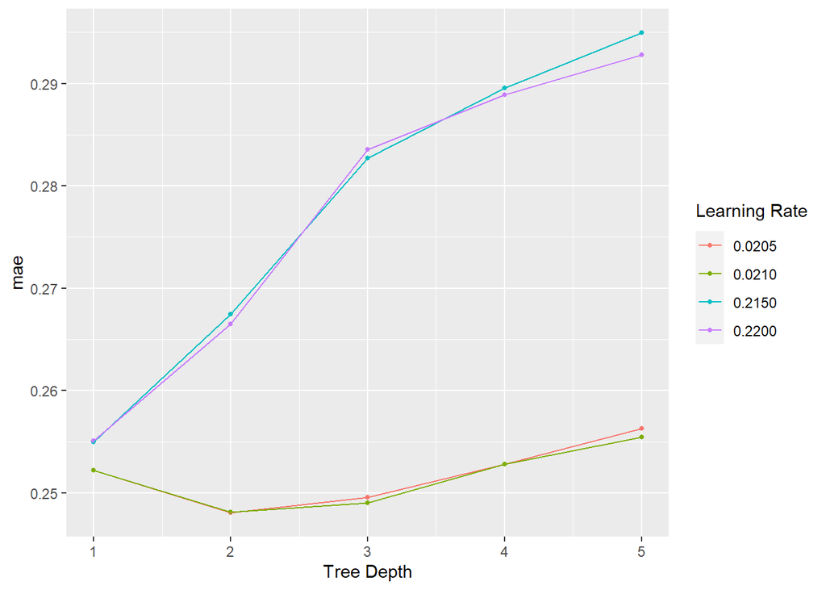

```r
all_data_gardien <- subset(Gardien, select = -c(nom, Poste, Club, Annee, Poste_global, tirsBloques))
all_data_gardien <- na.omit(all_data_gardien, cols = "Note")

#Diviser en entrainement et test
set.seed(123)
data_split_gar <- initial_split(all_data_gardien, prop = 0.75, strata = Note)
data_train_gar <- training(data_split_gar)
data_test_gar <- testing(data_split_gar)

#Préparation des données
variable_a_tester_xg <- c("Age","minJ","Apparences","But","PasseDecisive","Tirs","Dribbles","Passes_perc","moy_passes","centre_perc","interception","tacle","driblesSubis","fautes","TaclesRecu")
recipe_xg_gar <- recipe(Note ~ ., data = data_train_gar) |>
  update_role(all_of(variable_a_tester_xg), new_role = "predictor") |>
  step_normalize(all_predictors())

xgb_model_gar <-
  boost_tree(
    trees = 1000,
    stop_iter=20,
    min_n = 1,
    tree_depth = tune(),
    learn_rate = tune()
  ) |>
  set_mode("regression") |>
  set_engine("xgboost")

xgb_wf_gar <- workflow() |>
  add_recipe(recipe_xg_gar) |>
  add_model(xgb_model_gar)

play_samples_cv_gar <- vfold_cv(data_train_gar,v=3,repeats=1,strata="Note")

xgb_grid <- expand.grid(tree_depth=c(1,2,3,4,5),learn_rate=c(0.0205,0.0210, 0.215,0.220))

xgb_3fold_gar <- xgb_wf_gar |>
  tune_grid(resamples=play_samples_cv_gar,grid=xgb_grid,
            metrics=metric_set(mae))

xgb_3fold_gar |> autoplot()
```

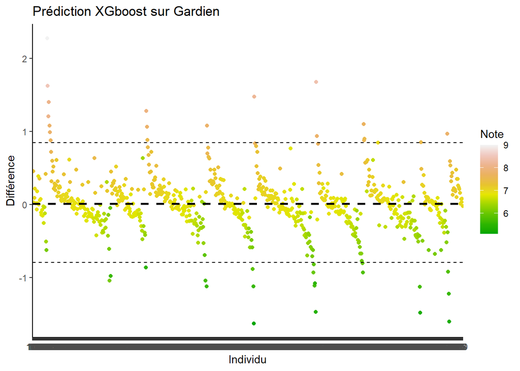

```r
best_par_gar <- xgb_3fold_gar |>
  select_best()

final_xgb_gar <- xgb_wf_gar |>
  finalize_workflow(best_par_gar) |>
  fit(data = data_train_gar)

pred_gar <- final_xgb_gar |>
  predict(new_data=data_test_gar)


data_test_gar_fin <- data_test_gar |> select(Note)
data_test_gar_fin_2 <- cbind(pred_gar, data_test_gar_fin)

data_test_gar_fin_2$Difference <- data_test_gar_fin_2$Note - data_test_gar_fin_2$.pred
data_test_gar_fin_2$DifferenceAbs <- abs(data_test_gar_fin_2$Note - data_test_gar_fin_2$.pred)


# Calculer la médiane et les intervalles de confiance
median_diff_gar <- median(data_test_gar_fin_2$Difference)
ci_low_gar <- quantile(data_test_gar_fin_2$Difference, 0.025)
ci_high_gar <- quantile(data_test_gar_fin_2$Difference, 0.975)

# Créer le plot ggplot2 avec médiane et intervalles de confiance
gg_plot_gar <- ggplot(data_test_gar_fin_2, aes(x = rownames(data_test_gar_fin_2), y = Difference, color = Note)) +
  geom_point() +
  geom_hline(yintercept = median_diff_gar, linetype = "dashed", color = "black", size = 1) +
  geom_hline(yintercept = ci_low_gar, linetype = "dashed", color = "black", size = 0.5)+
  geom_hline(yintercept = ci_high_gar, linetype = "dashed", color = "black", size = 0.5)+
  labs(title = "Prédiction XGboost sur Gardien",
       x = "Individu",
       y = "Différence") +
  scale_colour_gradientn(colours = terrain.colors(10)) +
  theme_classic()

gg_plot_gar
```

```r
R2_gar_xg <- 1 - sum((data_test_gar_fin_2$Note - data_test_gar_fin_2$.pred)^2) / sum((data_test_gar_fin_2$Note - mean(data_test_gar_fin_2$Note))^2)
RMSE_gar_xg <- sqrt(mean((data_test_gar_fin_2$Note - data_test_gar_fin_2$.pred)^2))
erreur_moy_abs_gar_xg <- mean(data_test_gar_fin_2$DifferenceAbs)
```